# The Impact of Technology Access on Earnigs

Group 06

January 28, 2019

# Step_0: Research Question and Variable Selection

**Research Questions:**

With a past of racial inequality in the southern states it would be interesting to examine how race/ethnicity is related to access to the internet and other technologies and how not having or having access could effect a persons earnings. This can be explored via the following research questions:

1. In the state of Alabama, how to earnings vary by access to the internet/technology?
2. Does the internet/technology premium vary by race and ethnicity?

**Variable Selection**:

To answer the research questions, this study looks at the variables which will reveal the demographic characteristics - such as “age” or “race”; socioeconomic status - such as “employment status” or “wage”; and the access to techonlogy - such as “access to internet.”

- The following variables will be included in this study. (Some other varialbes will be used as connector when joining tables but will not be included in the final dataframe.)
1. AGEP # Age: 0#99
2. SEMP # Self-employment income past 12 months (signed)
3. WAGP # Wages or salary income past 12 months
4. HISP # Recoded detailed Hispanic origin
5. NATIVITY # Nativity
6. PERNP # Total person’s earnings
7. RAC1P # Recoded detailed race code
8. RACAIAN # American Indian and Alaska Native recode
9. RACASN # Asian recode
10. RACBLK # Black or African American recode
11. RACNH # Native Hawaiian recode
12. RACWHT # White recode
13. WAOB # World area of birth
14. WKW #Weeks worked during past 12 months
15. ACCESS # Access to the Internet

# Step_1: System Setup

Before starting the program we need to clean the environment and import the library.

The loaded librariesin the code are:

1. tidyverse
2. here
3. DataExplorer

# Step_2: Data Cleaning

## Step_2.1: Import the raw data

Here we will import the raw data of personal income (ss16pal) into the dataframe as “base.”

```r
#load the persional data to variable Base
base <- read_csv(here('raw_data','ss16pal.csv'))%>%
  select(SERIALNO, #Serial Number to link House Hold and Personal data
         AGEP,  # Age: 0#99
         SEMP,  # Self-employment income past 12 months (signed)
         WAGP,  # Wages or salary income past 12 months
         HISP,  # Recoded detailed Hispanic origin
         NATIVITY,  # Nativity
         PERNP, # Total person's earnings
         RAC1P, # Recoded detailed race code
         RACAIAN, # American Indian and Alaska Native recode
         RACASN,  # Asian recode
         RACBLK,  # Black or African American recode
         RACNH, # Native Hawaiian recode
         RACWHT,  # White recode
         WAOB,  # World area of birth
         WKW)   #Weeks worked during past 12 months
```

We need to import the household level information (ss16hal) about internet access and merge the data into “base.”

```r
#Link the house hould data
househould <- read_csv(here('raw_data','ss16hal.csv'))%>%
  select(SERIALNO, #Serial Number to link House Hold and Personal data
        ACCESS # Access to the Internet
  )
base <- base %>% left_join(househould) %>% select(-SERIALNO)
rm(househould)
```

## Step_2.2: Structure of raw data

```r
str(base)
```

```
## Classes 'tbl_df', 'tbl' and 'data.frame':    47659 obs. of  15 variables:
##  $ AGEP    : chr  "84" "84" "78" "46" ...
##  $ SEMP    : chr  "0000000" "0000000" "0000000" "0000000" ...
##  $ WAGP    : chr  "0000000" "0000000" "0027300" "0065000" ...
##  $ HISP    : chr  "01" "01" "01" "01" ...
##  $ NATIVITY: int  1 1 1 1 1 1 1 1 1 1 ...
##  $ PERNP   : chr  "000000000" "000000000" "000027300" "000065000" ...
##  $ RAC1P   : int  1 1 1 1 1 1 1 1 1 1 ...
##  $ RACAIAN : int  0 0 0 0 0 0 0 0 0 0 ...
##  $ RACASN  : int  0 0 0 0 0 0 0 0 0 0 ...
##  $ RACBLK  : int  0 0 0 0 0 0 0 0 0 0 ...
##  $ RACNH   : int  0 0 0 0 0 0 0 0 0 0 ...
##  $ RACWHT  : int  1 1 1 1 1 1 1 1 1 1 ...
##  $ WAOB    : int  1 1 1 1 1 1 1 1 1 1 ...
##  $ WKW     : int  NA NA 1 1 NA NA NA NA NA 1 ...
##  $ ACCESS  : int  1 1 3 1 1 1 1 1 1 1 ...
```

Accoring to the first observation, some ordinary data will be converted into numerical type, and some categorical data will be converted into factor type.

## Step_2.3: Convert the variable types

Convert the categorical data into factor type and numetical data into numeric type. The factorial data in this dataframe will keep its representative code instead of the category name to save the memory space.

```r
#conver the catagorical variable type
base <- base %>% mutate(HISP= as.factor(HISP),
                        RAC1P= as.factor(RAC1P),
                        RACAIAN = as.factor(RACAIAN),
                        RACASN = as.factor(RACASN),
                        RACBLK = as.factor(RACBLK),
                        RACNH = as.factor(RACNH),
                        RACWHT = as.factor(RACWHT),
                        WAOB = as.factor(WAOB),
                        WKW = as.factor(WKW),
                        ACCESS = as.factor(ACCESS),
                        NATIVITY = as.factor(NATIVITY)
                        )

#conver the numeric variable type
base <- base %>% mutate(AGEP = as.numeric(AGEP),
                        SEMP= as.numeric(SEMP),
                        WAGP= as.numeric(WAGP),
                        PERNP= as.numeric(PERNP)
                        )
```

Replace the factor level to the choices in the survery question for easy understanding.

```r
levels(base$ACCESS) <- convertCSV2Factor("ACCESS")
levels(base$HISP) <- convertCSV2Factor("HISP")
levels(base$RAC1P) <- convertCSV2Factor("RAC1P")
levels(base$RACAIAN) <- convertCSV2Factor("RACAIAN")
levels(base$RACASN) <- convertCSV2Factor("RACASN")
levels(base$RACBLK) <- convertCSV2Factor("RACBLK")
levels(base$RACNH) <- convertCSV2Factor("RACNH")
levels(base$RACWHT) <- convertCSV2Factor("RACWHT")
levels(base$WKW) <- convertCSV2Factor("WKW")
levels(base$WAOB) <- convertCSV2Factor("WAOB")
levels(base$NATIVITY) <- convertCSV2Factor("NATIVITY")
```

==================

# Step_3: EDA

## Step_3.1 Brief of data structure

```
## Classes 'tbl_df', 'tbl' and 'data.frame':    47659 obs. of  15 variables:
##  $ AGEP    : num  84 84 78 46 52 20 16 66 68 64 ...
##  $ SEMP    : num  0 0 0 0 0 0 0 0 0 0 ...
##  $ WAGP    : num  0 0 27300 65000 0 0 0 0 0 78000 ...
##  $ HISP    : Factor w/ 23 levels "Not Spanish/Hispanic/Latino",..: 1 1 1 1 1 1 1 1 1 1 ...
##  $ NATIVITY: Factor w/ 2 levels "Native","Foreign born": 1 1 1 1 1 1 1 1 1 1 ...
##  $ PERNP   : num  0 0 27300 65000 0 0 0 0 0 78000 ...
##  $ RAC1P   : Factor w/ 8 levels "White","African American",..: 1 1 1 1 1 1 1 1 1 1 ...
##  $ RACAIAN : Factor w/ 2 levels "No","Yes": 1 1 1 1 1 1 1 1 1 1 ...
##  $ RACASN  : Factor w/ 2 levels "No","Yes": 1 1 1 1 1 1 1 1 1 1 ...
##  $ RACBLK  : Factor w/ 2 levels "No","Yes": 1 1 1 1 1 1 1 1 1 1 ...
##  $ RACNH   : Factor w/ 2 levels "No","Yes": 1 1 1 1 1 1 1 1 1 1 ...
##  $ RACWHT  : Factor w/ 2 levels "No","Yes": 2 2 2 2 2 2 2 2 2 2 ...
##  $ WAOB    : Factor w/ 8 levels "US state (POB = 001-059)",..: 1 1 1 1 1 1 1 1 1 1 ...
##  $ WKW     : Factor w/ 6 levels "50 to 52 weeks worked during past 12 months",..: NA NA 1 1 NA NA NA NA NA 1 ...
##  $ ACCESS  : Factor w/ 3 levels "Paid Access",..: 1 1 3 1 1 1 1 1 1 1 ...
```

## Step_3.2 Brief of data summary

```
##       AGEP            SEMP             WAGP
##  Min.   : 0.00   Min.   : -6800   Min.   :     0
##  1st Qu.:22.00   1st Qu.:     0   1st Qu.:     0
##  Median :44.00   Median :     0   Median :  1800
##  Mean   :42.54   Mean   :  1278   Mean   : 21782
##  3rd Qu.:62.00   3rd Qu.:     0   3rd Qu.: 31200
##  Max.   :93.00   Max.   :266000   Max.   :356000
##                  NA's   :7597     NA's   :7597
##                                 HISP               NATIVITY
##  Not Spanish/Hispanic/Latino      :46252   Native      :46324
##  Mexican                          :  842   Foreign born: 1335
##  Puerto Rican                     :  131
##  Guatemalan                       :   96
##  All Other Spanish/Hispanic/Latino:   88
##  Cuban                            :   48
##  (Other)                          :  202
##      PERNP                     RAC1P       RACAIAN     RACASN
##  Min.   : -6800   White           :34707   No :47142   No :46928
##  1st Qu.:     0   African American:10972   Yes:  517   Yes:  731
##  Median :  4550   Two more        :  734
##  Mean   : 23404   Asian           :  558
##  3rd Qu.: 34000   Others          :  439
##  Max.   :622000   American Indian :  185
##  NA's   :8185     (Other)         :   64
##  RACBLK      RACNH       RACWHT
##  No :36369   No :47646   No :12297
##  Yes:11290   Yes:   13   Yes:35362
##
##
##
##
##
##                                      WAOB
##  US state (POB = 001-059)              :45947
##  Latin America (POB = 303,310-399)     :  623
##  Asia (POB = 158-159,161,200-299)      :  553
##  Europe (POB = 100-157,160,162-199)    :  367
##  PR and US Island Areas (POB = 060-099):   62
##  Africa (POB = 400-499)                :   53
##  (Other)                               :   54
##                                               WKW
##  50 to 52 weeks worked during past 12 months    :16563
##  48 to 49 weeks worked during past 12 months    :  430
##  40 to 47 weeks worked during past 12 months    : 1116
##  27 to 39 weeks worked during past 12 months    : 1353
##  14 to 26 weeks worked during past 12 months    : 1166
##  less than 14 weeks worked during past 12 months: 1608
##  NA's                                           :25423
##          ACCESS
##  Paid Access:36959
##  Free Access: 1202
##  No Access  : 7186
##  NA's       : 2312
##
##
##
```

## Step_3.3 Missing data

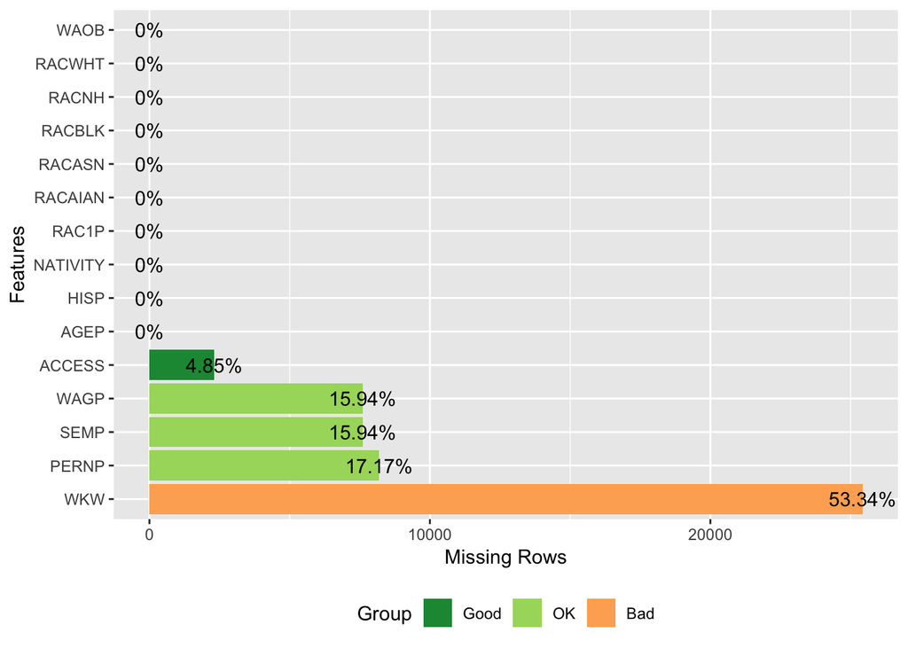

The variable of “WKW”, Weeks worked during past 12 months, has a great amount of missing data.

## Step_3.4 Brief of “Age Dispersion”

```r
base %>% select(AGEP) %>%  summary()
```

```
##       AGEP
##  Min.   : 0.00
##  1st Qu.:22.00
##  Median :44.00
##  Mean   :42.54
##  3rd Qu.:62.00
##  Max.   :93.00
```

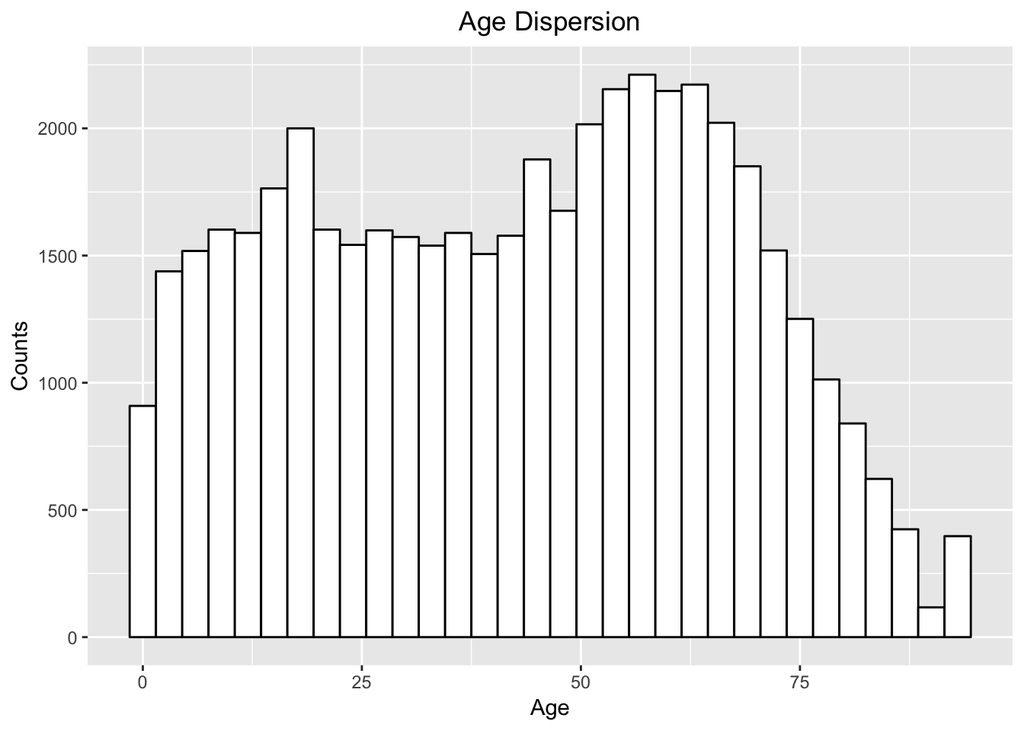

```r
base %>% ggplot(aes(AGEP)) + geom_histogram(binwidth = 3, fill = "white", colour = "black") + xlab("Age") + ylab("Counts") + ggtitle("Age Dispersion") + theme(plot.title = element_text(hjust = 0.5))
```

## Step_3.5 Brief of “Wage”

- Summary of wages

```r
summary(base$WAGP)
```

```
##    Min. 1st Qu.  Median    Mean 3rd Qu.    Max.    NA's
##       0       0    1800   21782   31200  356000    7597
```

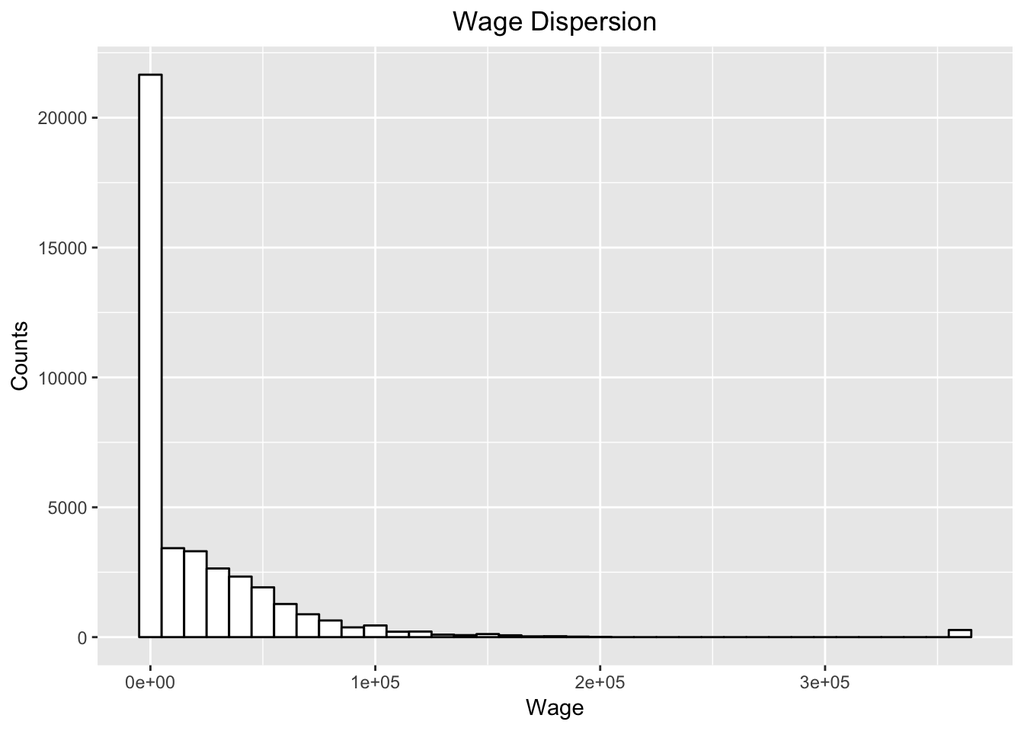

```r
base %>% ggplot(aes(WAGP)) + geom_histogram(binwidth = 10000, fill = "white", colour = "black") + xlab("Wage") + ylab("Counts") + ggtitle("Wage Dispersion") + theme(plot.title = element_text(hjust = 0.5))
```

- Density of wages

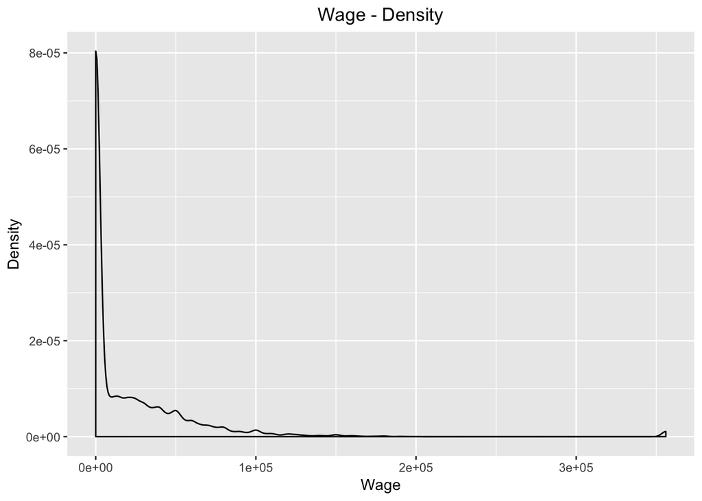

```r
base  %>% ggplot(aes(x = WAGP)) + geom_density() + xlab("Wage") +ylab("Density") + ggtitle("Wage - Density") + theme(plot.title = element_text(hjust = 0.5))
```

- Box plot of wages by races

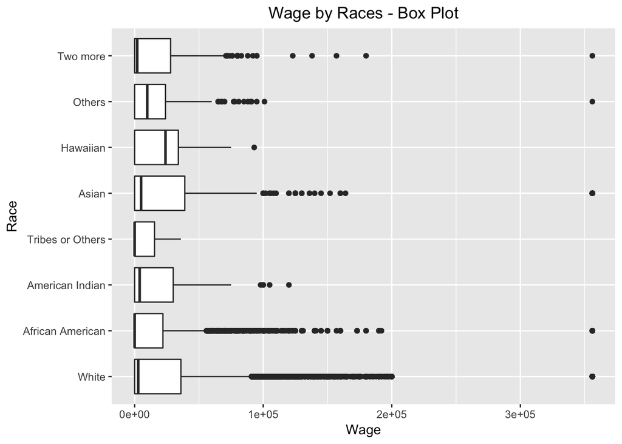

```r
ggplot(data = base, aes(x = RAC1P, y = WAGP)) + geom_boxplot() + coord_flip() + xlab("Race") + ylab("Wage") + ggtitle("Wage by Races - Box Plot") + theme(plot.title = element_text(hjust = 0.5))
```

- Density of wages by races

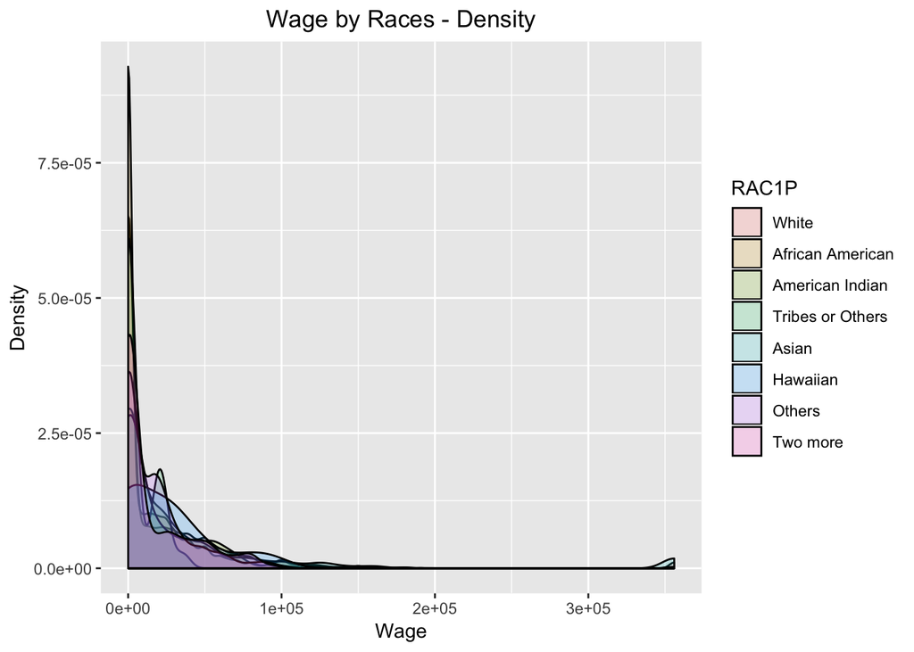

```r
ggplot(data = base, aes(x = WAGP, fill = RAC1P)) + geom_density(alpha = .2) + xlab("Wage") + ylab("Density") + ggtitle("Wage by Races - Density") + theme(plot.title = element_text(hjust = 0.5))
```

**Note:**

| category in the graphs above | corresponding title in the survey |
| --- | --- |
| Two more | Two or More Races |
| Others | Some Other Race alone |
| Hawaiian | Native Hawaiian and Other Pacific Islander alone |
| Asian | Asian alone |
| Tribes or Others | American Indian and Alaska Native tribes specified; or American Indian or Alaska Native, not specified and no other races |
| American Indian | American Indian alone |
| African American | Black or African American alone |
| White | White alone |

## Step_3.6 Brief of “Access to Internet”

- Summary of access to internet

```r
summary(base$ACCESS)
```

```
## Paid Access Free Access   No Access        NA's
##       36959        1202        7186        2312
```

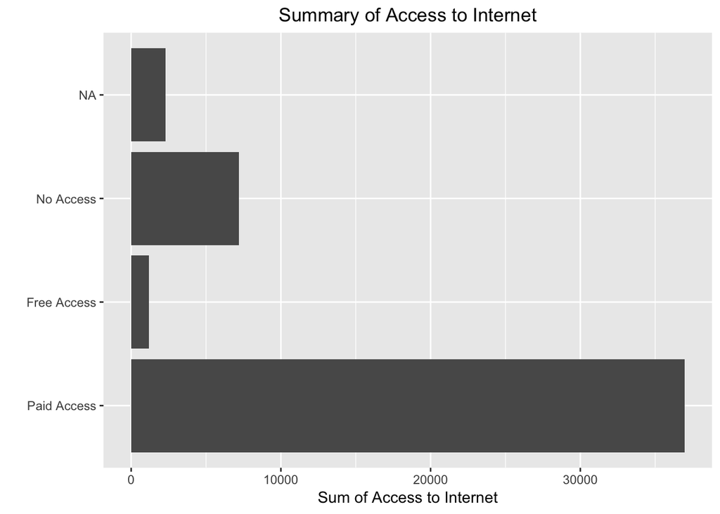

```r
ggplot(data = base, aes(x = ACCESS)) + geom_bar() + xlab("") + ylab("Sum of Access to Internet") + coord_flip() + ggtitle("Summary of Access to Internet") + theme(plot.title = element_text(hjust = 0.5))
```

- Summary of access to internet by races

```r
base2 <- base %>%
        select(c("RAC1P","ACCESS")) %>%
        group_by(RAC1P, ACCESS) %>%
        summarise(counts = n())
```

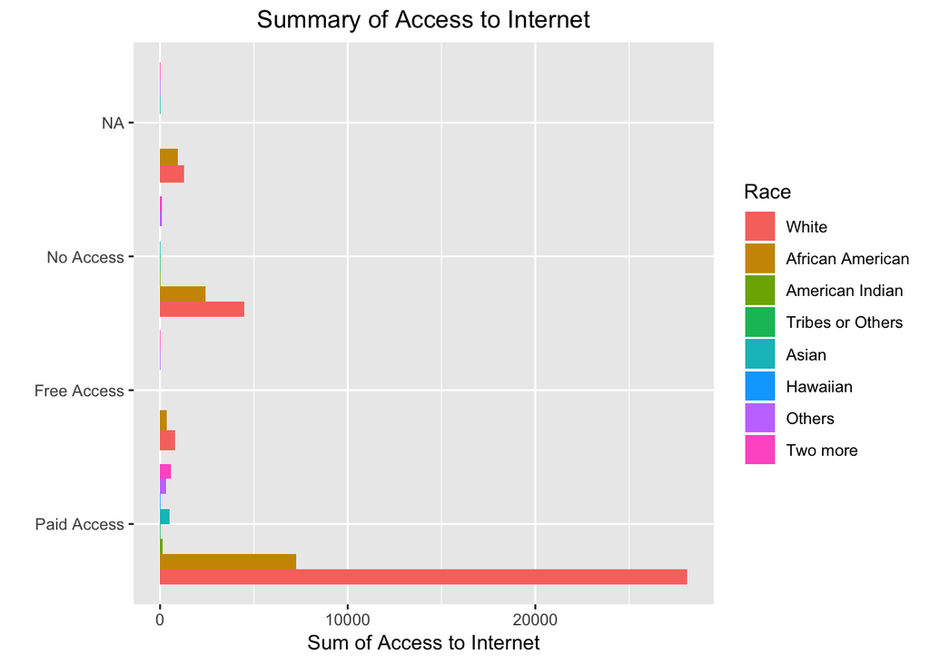

```r
ggplot(data = base2, aes(x = ACCESS, y = counts, fill = RAC1P)) + geom_col(position = "dodge") + coord_flip() + xlab("") + ylab("Sum of Access to Internet")  + ggtitle("Summary of Access to Internet") + theme(plot.title = element_text(hjust = 0.5)) + labs(fill = "Race")
```

```r
rm("base2")
```

# Step_4: Criteria for filtering the data

**1. Tolerance for missing data:**

The tolerance for missing date varies by research topic. The tolerance for missing data is arbitory in this study is arbitrarily set at 50% - **the missing records in a variable should not be more than half of the total observations (Data Filtering Criteria 1)**.

Because the variable of **“WKW”**, weeks worked during past 12 months, has about 53.34% of missing data over all observation, this variable will be **REMOVED**.

```r
base$WKW <- NULL
```

**2. Age range:**

The ages of cases covered in the survey are ranging from **0 year old to 93 years old**. There is **no missing value** under the age category.

According to the regulation from US Department of Labor, the legal working age is 14 (for most non-agricultural work), and the early retirement age is 62. This study will looks at the **age group of 14~62 years old (Data Filtering Criteria 2)**.

```r
base <- base %>%
        mutate( age_group = case_when(
                            AGEP < 14 ~ "Other ages (exclude)",
                            AGEP >= 14 & AGEP <= 62 ~ "Age 14-62 (include)",
                            AGEP > 62 ~ "Other ages (exclude)"
        ))
base$age_group <- as.factor(base$age_group)
```

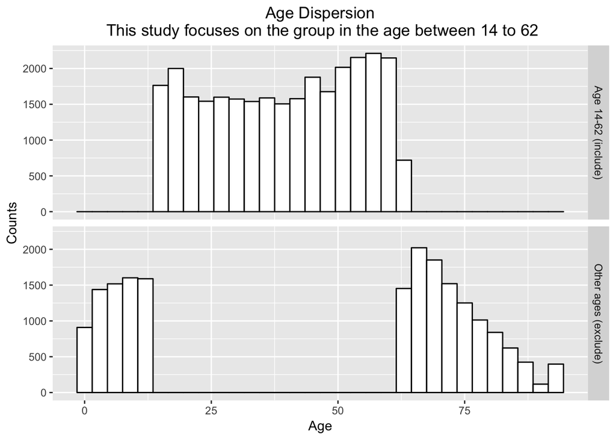

```r
base %>% ggplot(aes(AGEP)) + geom_histogram(binwidth = 3, fill = "white", colour = "black") + xlab("Age") + ylab("Counts") + ggtitle("Age Dispersion\n This study focuses on the group in the age between 14 to 62") + theme(plot.title = element_text(hjust = 0.5)) + facet_grid(age_group ~ .)
```

Remove the records which are out of the age group of 14 to 62.

```r
base <- base %>%  filter(AGEP>=14 & AGEP <= 62)
base$age_group <- NULL
```

**3. Wage:**

This study excludes the out-liers of super rich and upper level, which do not contribute to the discussion of premium from access to internet. Considering the hourly wage in US was $7.25 back to 2014 and this study considering people working more than 40 weeks as the full time employees, this minimum income for full-time emloyees would be 7.25 USD/Hour * 40 Weeks * 40 Hours/Week = 11600 USD. **Yearly wage from 11,600 up to the third quartile(54,000) will be included in this study (Data Filtering Criteria 2)**. The miss data and rests will be removed.

```r
base <- base %>%  filter(WAGP<54000 & WAGP > 11600)
```

# Step_5: Data summary - After the restriction

```r
summary(base)
```

```
##       AGEP            SEMP               WAGP
##  Min.   :16.00   Min.   : -6800.0   Min.   :11700
##  1st Qu.:30.00   1st Qu.:     0.0   1st Qu.:20000
##  Median :41.00   Median :     0.0   Median :30000
##  Mean   :40.79   Mean   :   364.2   Mean   :30322
##  3rd Qu.:52.00   3rd Qu.:     0.0   3rd Qu.:40000
##  Max.   :62.00   Max.   :266000.0   Max.   :53000
##
##                                 HISP              NATIVITY
##  Not Spanish/Hispanic/Latino      :9935   Native      :9875
##  Mexican                          : 210   Foreign born: 410
##  Guatemalan                       :  30
##  Puerto Rican                     :  28
##  All Other Spanish/Hispanic/Latino:  19
##  Salvadoran                       :   9
##  (Other)                          :  54
##      PERNP                     RAC1P      RACAIAN     RACASN
##  Min.   :  5600   White           :7448   No :10178   No :10141
##  1st Qu.: 20000   African American:2423   Yes:  107   Yes:  144
##  Median : 30000   Others          : 126
##  Mean   : 30687   Asian           : 114
##  3rd Qu.: 40000   Two more        : 110
##  Max.   :316000   American Indian :  47
##                   (Other)         :  17
##  RACBLK     RACNH       RACWHT
##  No :7824   No :10283   No :2736
##  Yes:2461   Yes:    2   Yes:7549
##
##
##
##
##
##                                      WAOB              ACCESS
##  US state (POB = 001-059)              :9779   Paid Access:8835
##  Latin America (POB = 303,310-399)     : 247   Free Access: 269
##  Asia (POB = 158-159,161,200-299)      : 131   No Access  :1007
##  Europe (POB = 100-157,160,162-199)    :  88   NA's       : 174
##  Africa (POB = 400-499)                :  14
##  PR and US Island Areas (POB = 060-099):  13
##  (Other)                               :  13
```

==================

# Step_6: Examine access to the internet and its relation to earnings.

```r
base %>% select(ACCESS) %>% summary()
```

```
##          ACCESS
##  Paid Access:8835
##  Free Access: 269
##  No Access  :1007
##  NA's       : 174
```

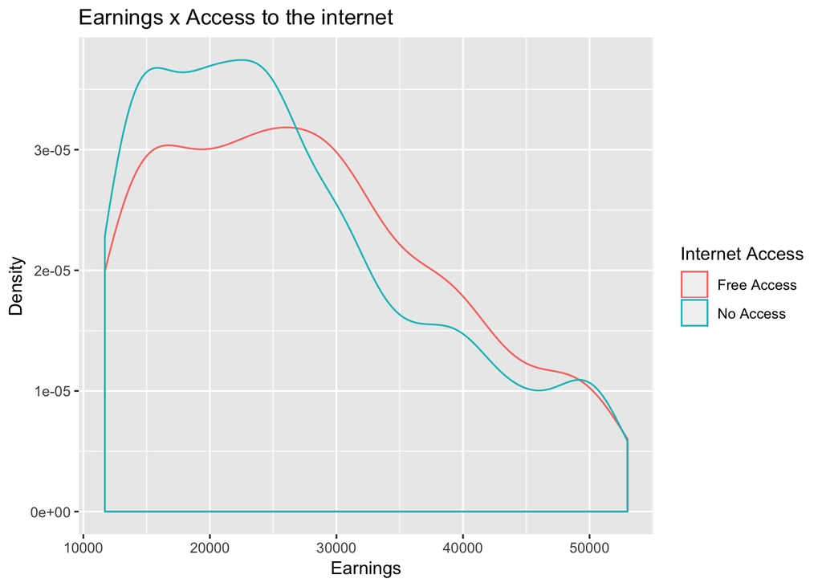

```r
base %>%  filter(!is.na(ACCESS) & ACCESS != "Paid Access") %>%
  ggplot(aes(WAGP,color=ACCESS)) + geom_density() +
  labs(title="Earnings x Access to the internet",
       x ="Earnings", y = "Density") +
  scale_color_discrete(name="Internet Access",
                      labels=c("Free Access", "No Access"))
```

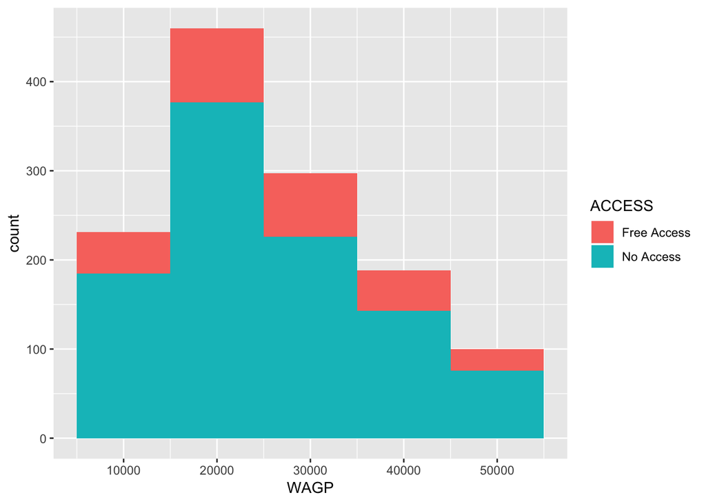

```r
base %>%  filter(!is.na(ACCESS) & ACCESS != "Paid Access") %>%
  ggplot() + geom_histogram(aes(x=WAGP,fill=ACCESS), binwidth = 10000)
```

```r
base %>%
  filter(!is.na(ACCESS) & ACCESS != "Paid Access") %>%
  group_by(ACCESS, RAC1P) %>%
  summarise (mean(WAGP),sd(WAGP),min(WAGP),max(WAGP), median(WAGP))
```

```
## # A tibble: 12 x 7
## # Groups:   ACCESS [?]
##    ACCESS RAC1P `mean(WAGP)` `sd(WAGP)` `min(WAGP)` `max(WAGP)`
##    <fct>  <fct>        <dbl>      <dbl>       <dbl>       <dbl>
##  1 Free … White       28046.     10882.       12000       52000
##  2 Free … Afri…       28201.     11011.       11700       52000
##  3 Free … Amer…       18800         NA        18800       18800
##  4 Free … Othe…       31000      26870.       12000       50000
##  5 Free … Two …       13667.      1528.       12000       15000
##  6 No Ac… White       28067.     11183.       11800       53000
##  7 No Ac… Afri…       24580.     10277.       11700       52000
##  8 No Ac… Amer…       23267.      2053.       21000       25000
##  9 No Ac… Trib…       20000         NA        20000       20000
## 10 No Ac… Asian       28500      12021.       20000       37000
## 11 No Ac… Othe…       20534.      9319.       12000       49000
## 12 No Ac… Two …       30008.      9252.       13600       48000
## # ... with 1 more variable: `median(WAGP)` <dbl>
```

## Step_7 Race and access to the internet

```r
base %>% select(RAC1P) %>% summary()
```

```
##               RAC1P
##  White           :7448
##  African American:2423
##  Others          : 126
##  Asian           : 114
##  Two more        : 110
##  American Indian :  47
##  (Other)         :  17
```

```r
base %>% filter(ACCESS=="No Access") %>% select(RAC1P) %>% summary() #person doesn't have ACCESS to Internet
```

```
##               RAC1P
##  White           :593
##  African American:366
##  Others          : 29
##  Two more        : 13
##  American Indian :  3
##  Asian           :  2
##  (Other)         :  1
```

[figure not shown]

```r
base %>%  filter(!is.na(ACCESS) & ACCESS != "Paid Access") %>%
  ggplot() + geom_bar(aes(x = RAC1P, fill=ACCESS)) +
  coord_flip() +
  xlab('Race') +
  scale_x_discrete(labels = c('White', 'Black', 'Native American', "Multiple tribes", "Asian", 'Pacific Islander', 'Other', 'Two or more Races')) +
  theme(legend.position= c(0.87,0.85))
```

**Building the model**

```r
base_model <- base %>%
  filter(!is.na(ACCESS) & ACCESS != "Paid Access") %>%
  mutate(free_access = ACCESS == "Free Access",
         hispanic = HISP != "Not Spanish/Hispanic/Latino",
         black = RACBLK == "Yes"
         )

model_01 <- lm(WAGP ~ free_access, data = base_model)

model_01 %>% summary()
```

```
##
## Call:
## lm(formula = WAGP ~ free_access, data = base_model)
##
## Residuals:
##    Min     1Q Median     3Q    Max
## -16223  -8587  -1587   7077  26413
##
## Coefficients:
##                 Estimate Std. Error t value Pr(>|t|)
## (Intercept)      26586.7      345.2  77.022   <2e-16 ***
## free_accessTRUE   1336.0      751.8   1.777   0.0758 .
## ---
## Signif. codes:  0 '***' 0.001 '**' 0.01 '*' 0.05 '.' 0.1 ' ' 1
##
## Residual standard error: 10950 on 1274 degrees of freedom
## Multiple R-squared:  0.002473,   Adjusted R-squared:  0.00169
## F-statistic: 3.158 on 1 and 1274 DF,  p-value: 0.0758
```

```r
model_02 <- lm(WAGP ~ free_access + hispanic + black, data = base_model)
model_02 %>% summary()
```

```
##
## Call:
## lm(formula = WAGP ~ free_access + hispanic + black, data = base_model)
##
## Residuals:
##    Min     1Q Median     3Q    Max
## -16969  -8585  -1968   7063  27341
##
## Coefficients:
##                 Estimate Std. Error t value Pr(>|t|)
## (Intercept)      27937.2      430.5  64.890  < 2e-16 ***
## free_accessTRUE   1031.5      746.4   1.382 0.167257
## hispanicTRUE     -5278.3     1425.2  -3.704 0.000222 ***
## blackTRUE        -2870.2      643.4  -4.461 8.87e-06 ***
## ---
## Signif. codes:  0 '***' 0.001 '**' 0.01 '*' 0.05 '.' 0.1 ' ' 1
##
## Residual standard error: 10840 on 1272 degrees of freedom
## Multiple R-squared:  0.02453,    Adjusted R-squared:  0.02223
## F-statistic: 10.66 on 3 and 1272 DF,  p-value: 6.325e-07
```